# ML_Assignment4_Swathi_Ganesan

```python
import pandas as pd
import numpy as np
import matplotlib.pyplot as plt
import os

import seaborn as sns
from scipy import stats

from sklearn.model_selection import train_test_split, GridSearchCV, RandomizedSearchCV

from sklearn.ensemble import RandomForestClassifier
from sklearn.svm import SVC, LinearSVC

from sklearn.metrics import confusion_matrix, classification_report, roc_auc_score
from sklearn.metrics import mean_squared_error,r2_score,explained_variance_score

import warnings
warnings.simplefilter(action='ignore', category=FutureWarning)
```

### 1 Data Processing

##### a) Import the data

```python
train = pd.read_csv ('train_data.csv')
test = pd.read_csv ('test_data.csv')
```

```python
train.shape
```

```
(507, 148)
```

```python
test.shape
```

```
(168, 148)
```

```python
train.describe()
```

|  | BrdIndx | Area | Round | Bright | Compact | ShpIndx | Mean_G | Mean_R | Mean_NIR | SD_G | ... | SD_NIR_140 | LW_140 | GLCM1_140 | Rect_140 | GLCM2_140 | Dens_140 | Assym_140 | NDVI_140 | BordLngth_140 | GLCM3_140 |
| --- | --- | --- | --- | --- | --- | --- | --- | --- | --- | --- | --- | --- | --- | --- | --- | --- | --- | --- | --- | --- | --- |
| count | 507.000000 | 507.000000 | 507.000000 | 507.000000 | 507.000000 | 507.000000 | 507.000000 | 507.000000 | 507.000000 | 507.000000 | ... | 507.000000 | 507.000000 | 507.000000 | 507.000000 | 507.000000 | 507.000000 | 507.000000 | 507.000000 | 507.000000 | 507.000000 |
| mean | 2.025720 | 562.504931 | 1.237574 | 165.612939 | 2.187081 | 2.277318 | 166.290355 | 162.291953 | 168.256667 | 10.725227 | ... | 24.601144 | 2.931657 | 0.817712 | 0.597732 | 8.048698 | 1.455838 | 0.653905 | 0.027436 | 1398.706114 | 1101.998185 |
| std | 0.619254 | 698.655240 | 0.561988 | 63.230806 | 0.874054 | 0.718441 | 59.217648 | 73.455101 | 69.702475 | 4.968761 | ... | 12.203441 | 4.942887 | 0.106007 | 0.197505 | 0.787912 | 0.451781 | 0.251287 | 0.133834 | 1097.323462 | 533.927869 |
| min | 1.000000 | 22.000000 | 0.000000 | 26.850000 | 1.000000 | 1.040000 | 22.910000 | 26.520000 | 31.110000 | 3.550000 | ... | 2.650000 | 1.000000 | 0.200000 | 0.100000 | 5.690000 | 0.240000 | 0.030000 | -0.360000 | 34.000000 | 211.270000 |
| 25% | 1.580000 | 159.000000 | 0.840000 | 127.485000 | 1.650000 | 1.715000 | 146.460000 | 97.585000 | 111.715000 | 6.985000 | ... | 14.485000 | 1.375000 | 0.770000 | 0.455000 | 7.370000 | 1.160000 | 0.470000 | -0.080000 | 601.000000 | 726.745000 |
| 50% | 1.950000 | 323.000000 | 1.210000 | 170.650000 | 2.000000 | 2.180000 | 189.630000 | 158.280000 | 167.750000 | 9.290000 | ... | 22.380000 | 1.920000 | 0.840000 | 0.610000 | 8.020000 | 1.440000 | 0.710000 | -0.020000 | 1148.000000 | 1011.230000 |
| 75% | 2.380000 | 681.500000 | 1.565000 | 224.825000 | 2.490000 | 2.675000 | 206.780000 | 237.375000 | 238.480000 | 13.330000 | ... | 33.825000 | 2.800000 | 0.890000 | 0.760000 | 8.750000 | 1.775000 | 0.860000 | 0.145000 | 1874.000000 | 1335.640000 |
| max | 4.530000 | 5767.000000 | 3.520000 | 245.870000 | 8.070000 | 5.410000 | 239.370000 | 253.610000 | 253.630000 | 30.870000 | ... | 61.340000 | 64.700000 | 0.970000 | 1.000000 | 9.570000 | 2.410000 | 1.000000 | 0.370000 | 8896.000000 | 3619.280000 |

8 rows × 147 columns

##### b) Remove any rows that have missing data across both sets of data

```python
train.dropna(inplace=True)
test.dropna(inplace=True)
```

```python
train.shape
```

```
(507, 148)
```

```python
test.shape
```

```
(168, 148)
```

##### c) The target variable (dependent variable) is called "class", make sure to separate this out into a "y_train" and "y_test" and remove from your "X_train" and "X_test".

```python
X_train = train.drop('class', axis=1)
y_train = train['class'].to_numpy()


X_test = test.drop('class', axis=1)
y_test = test['class'].to_numpy()
```

##### d) Scale all features / predictors (NOT THE TARGET VARIABLE)

```python
from sklearn.preprocessing import StandardScaler

# creating a StandardScaler object
scaler = StandardScaler()

# fitting the scaler to the training data and transform the data
X_train_scaled = scaler.fit_transform(X_train)

# transforming the test data using the scaling parameters learned from the training data
X_test_scaled = scaler.transform(X_test)
```

```python
X_train_scaled
```

```
array([[-1.14075473, -0.61823212, -0.76157526, ..., -0.95313273,
         0.10334763,  0.34780924],
       [-0.70431561,  0.43196247, -0.53002518, ..., -1.25230517,
        -1.09711859,  2.92039508],
       [-0.99527502, -0.21993185, -0.42315592, ...,  0.5427295 ,
        -0.1830858 , -0.71544325],
       ...,
       [ 0.68582378,  0.13825184,  0.25368276, ..., -0.87833962,
         1.09218151,  0.26440108],
       [-0.20321885, -0.67840698, -0.40534437, ..., -1.10271895,
        -0.61364815,  0.6910969 ],
       [ 0.73431702, -0.58384648,  0.78802909, ..., -1.02792584,
        -1.00589775,  1.66713547]])
```

### 2 Random Forest Classifier - Base Model

##### a) Use the RandomForestClassifier in sklearn. Fit your model on the training data.

```python
# fit random forest classifier on training data
rfc = RandomForestClassifier(random_state=42)
rfc.fit(X_train_scaled, y_train)
```

```
RandomForestClassifier(random_state=42)
```

##### b) Use the fitted model to predict on test data. Use the .predict() method to get the predicted classes.

```python
# predict on test data
y_pred_rfc = rfc.predict(X_test_scaled)
y_pred_proba_rfc = rfc.predict_proba(X_test_scaled)
```

##### c) Calculate the confusion matrix and classification report for the test data

```python
# calculate confusion matrix and classification report
print("Confusion Matrix: \n", confusion_matrix(y_test, y_pred_rfc))
print("\nClassification Report: \n", classification_report(y_test, y_pred_rfc))
```

```
Confusion Matrix:
 [[14  0  0  0  0  0  0  0  0]
 [ 1 22  0  2  0  0  0  0  0]
 [ 1  1 13  0  0  0  0  0  0]
 [ 0  5  0 18  0  0  0  0  0]
 [ 0  0  0  0 25  0  0  0  4]
 [ 1  0  1  0  0 13  0  0  0]
 [ 3  0  0  0  0  0 13  0  0]
 [ 0  1  0  5  3  0  0  5  0]
 [ 0  0  0  1  1  0  0  0 15]]

Classification Report:
               precision    recall  f1-score   support

    asphalt        0.70      1.00      0.82        14
   building        0.76      0.88      0.81        25
        car        0.93      0.87      0.90        15
   concrete        0.69      0.78      0.73        23
      grass        0.86      0.86      0.86        29
       pool        1.00      0.87      0.93        15
     shadow        1.00      0.81      0.90        16
       soil        1.00      0.36      0.53        14
       tree        0.79      0.88      0.83        17

    accuracy                           0.82       168
   macro avg       0.86      0.81      0.81       168
weighted avg       0.85      0.82      0.82       168
```

##### d) Calculate predictions for the training data & build the classification report & confusion matrix. Are there signs of overfitting? Why or why not?

```python
# predict for train data and build confusion matrix and classification report
y_pred_train_rfc = rfc.predict(X_train_scaled)
print("Confusion Matrix: \n", confusion_matrix(y_train, y_pred_train_rfc))
print("Classification Report: \n", classification_report(y_train, y_pred_train_rfc))
```

```
Confusion Matrix:
 [[45  0  0  0  0  0  0  0  0]
 [ 0 97  0  0  0  0  0  0  0]
 [ 0  0 21  0  0  0  0  0  0]
 [ 0  0  0 93  0  0  0  0  0]
 [ 0  0  0  0 83  0  0  0  0]
 [ 0  0  0  0  0 14  0  0  0]
 [ 0  0  0  0  0  0 45  0  0]
 [ 0  0  0  0  0  0  0 20  0]
 [ 0  0  0  0  0  0  0  0 89]]
Classification Report:
               precision    recall  f1-score   support

    asphalt        1.00      1.00      1.00        45
   building        1.00      1.00      1.00        97
        car        1.00      1.00      1.00        21
   concrete        1.00      1.00      1.00        93
      grass        1.00      1.00      1.00        83
       pool        1.00      1.00      1.00        14
     shadow        1.00      1.00      1.00        45
       soil        1.00      1.00      1.00        20
       tree        1.00      1.00      1.00        89

    accuracy                           1.00       507
   macro avg       1.00      1.00      1.00       507
weighted avg       1.00      1.00      1.00       507
```

Moreover, the weighted average F1-score of the test set is 0.82, while the weighted average F1-score of the training set is 1.00. This difference in performance between the training and test sets suggests that the model may have overfit to the training data and is not generalizing well to new data.

##### e) Identify the top 5 features. Feel free to print a list OR to make a plot

```
Top 5 important features of Random Forest Classifier:  ['NDVI' 'Mean_NIR' 'Mean_R_40' 'NDVI_60' 'Mean_NIR_40']
```

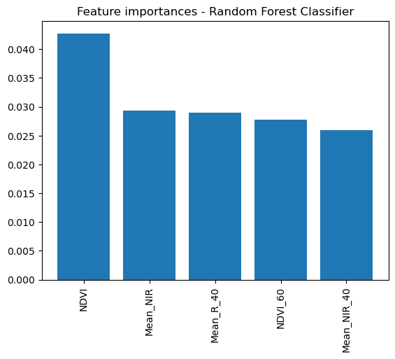

```python
# identify top 5 features
importances = rfc.feature_importances_
indices = np.argsort(importances)[::-1][:5]
print("Top 5 important features of Random Forest Classifier: ", X_train.columns[indices].values)
plt.figure()
plt.title("Feature importances - Random Forest Classifier")
plt.bar(range(5), importances[indices])
plt.xticks(range(5), X_train.columns[indices], rotation=90)
plt.show()
```

### 3 LinearSVM Classifier - Base Model

##### a) Use the LinearSVC in sklearn. Fit your model on the training data

```python
# create and fit LinearSVC classifier on train data
linear_svc = LinearSVC(random_state=42, max_iter=10000)
linear_svc.fit(X_train_scaled, y_train)
```

```
LinearSVC(max_iter=10000, random_state=42)
```

##### b) Use the fitted model to predict on test data. Use the .predict() method to get the predicted classes

```python
# predict on test data
y_pred_linsvc = linear_svc.predict(X_test_scaled)
```

##### c) Calculate the confusion matrix and classification report for test data

```python
# calculate confusion matrix and classification report
print("Confusion Matrix: \n", confusion_matrix(y_test, y_pred_linsvc))
print("\nClassification Report: \n", classification_report(y_test, y_pred_linsvc))
```

```
Confusion Matrix:
 [[13  0  0  0  0  0  1  0  0]
 [ 0 22  1  1  1  0  0  0  0]
 [ 0  2 12  0  0  0  0  0  1]
 [ 1  6  0 15  0  0  0  0  1]
 [ 0  0  0  1 26  0  0  0  2]
 [ 1  0  1  0  0 13  0  0  0]
 [ 2  0  0  0  0  0 14  0  0]
 [ 0  4  0  1  3  0  0  6  0]
 [ 0  0  0  1  7  0  0  0  9]]

Classification Report:
               precision    recall  f1-score   support

    asphalt        0.76      0.93      0.84        14
   building        0.65      0.88      0.75        25
        car        0.86      0.80      0.83        15
   concrete        0.79      0.65      0.71        23
      grass        0.70      0.90      0.79        29
       pool        1.00      0.87      0.93        15
     shadow        0.93      0.88      0.90        16
       soil        1.00      0.43      0.60        14
       tree        0.69      0.53      0.60        17

    accuracy                           0.77       168
   macro avg       0.82      0.76      0.77       168
weighted avg       0.80      0.77      0.77       168
```

##### d) Calculate predictions for the training data & build the classification report & confusion matrix. Are there signs of overfitting? Why or why not?

```python
# predict for train data and build confusion matrix and classification report
y_pred_train_linsvc = linear_svc.predict(X_train_scaled)
print("Confusion Matrix: \n", confusion_matrix(y_train, y_pred_train_linsvc))
print("Classification Report: \n", classification_report(y_train, y_pred_train_linsvc))
```

```
Confusion Matrix:
 [[45  0  0  0  0  0  0  0  0]
 [ 0 97  0  0  0  0  0  0  0]
 [ 0  0 21  0  0  0  0  0  0]
 [ 0  0  0 93  0  0  0  0  0]
 [ 0  1  0  0 80  0  0  0  2]
 [ 0  0  0  0  0 14  0  0  0]
 [ 0  0  0  0  0  0 45  0  0]
 [ 0  0  0  0  0  0  0 20  0]
 [ 0  0  0  0  0  0  0  0 89]]
Classification Report:
               precision    recall  f1-score   support

    asphalt        1.00      1.00      1.00        45
   building        0.99      1.00      0.99        97
        car        1.00      1.00      1.00        21
   concrete        1.00      1.00      1.00        93
      grass        1.00      0.96      0.98        83
       pool        1.00      1.00      1.00        14
     shadow        1.00      1.00      1.00        45
       soil        1.00      1.00      1.00        20
       tree        0.98      1.00      0.99        89

    accuracy                           0.99       507
   macro avg       1.00      1.00      1.00       507
weighted avg       0.99      0.99      0.99       507
```

The lower performance of the model on the test data compared to the train data suggests that the model is overfitting to the training data.

### 4 Support Vector Machine Classifier + Linear Kernel + Grid Search

##### a) Use SVC from sklearn with kernel = "linear". Run the GridSearchCV using the following (SVMs run much faster than RandomForest):

```
C: 0.01 - 10 in increments of 0.2 (consider using the np.arange() method from numpy to build out a sequence of values)
Use 5 cross-fold and the default scoring. Please set verbose = 0 to reduce the printing
```

```python
# create an instance of SVM with a linear kernel
svc = SVC(kernel='linear', random_state=42)

# specify the parameters to be tuned
parameters = {'C': np.arange(0.01, 10.2, 0.2)}

# create a GridSearchCV object with 5-fold cross-validation
grid_search_svc = GridSearchCV(svc, parameters, cv=5, verbose=0, n_jobs=-1)

# fit the GridSearchCV object to the data
grid_search_svc.fit(X_train_scaled, y_train)
```

```
GridSearchCV(cv=5, estimator=SVC(kernel='linear', random_state=42), n_jobs=-1,
             param_grid={'C': array([1.000e-02, 2.100e-01, 4.100e-01, 6.100e-01, 8.100e-01, 1.010e+00,
       1.210e+00, 1.410e+00, 1.610e+00, 1.810e+00, 2.010e+00, 2.210e+00,
       2.410e+00, 2.610e+00, 2.810e+00, 3.010e+00, 3.210e+00, 3.410e+00,
       3.610e+00, 3.810e+00, 4.010e+00, 4.210e+00, 4.410e+00, 4.610e+00,
       4.810e+00, 5.010e+00, 5.210e+00, 5.410e+00, 5.610e+00, 5.810e+00,
       6.010e+00, 6.210e+00, 6.410e+00, 6.610e+00, 6.810e+00, 7.010e+00,
       7.210e+00, 7.410e+00, 7.610e+00, 7.810e+00, 8.010e+00, 8.210e+00,
       8.410e+00, 8.610e+00, 8.810e+00, 9.010e+00, 9.210e+00, 9.410e+00,
       9.610e+00, 9.810e+00, 1.001e+01])})
```

##### b) Identify the best performing model:

```python
# print the best parameters
print(grid_search_svc.best_params_)

# print the best estimator
best_model_svc = grid_search_svc.best_estimator_
print(best_model_svc)
```

```
{'C': 0.01}
SVC(C=0.01, kernel='linear', random_state=42)
```

##### c) Use the best estimator model to predict on test data. Use the .predict() method to get the predicted classes.

```python
# predict on the test data
y_pred_svc = best_model_svc.predict(X_test_scaled)
```

##### d) Calculate the confusion matrix and classification report for test data.

```python
# calculate confusion matrix and classification report
print("Confusion Matrix: \n", confusion_matrix(y_test, y_pred_svc))
print("\nClassification Report: \n", classification_report(y_test, y_pred_svc))
```

```
Confusion Matrix:
 [[13  0  0  0  0  0  1  0  0]
 [ 0 22  0  2  1  0  0  0  0]
 [ 0  1 14  0  0  0  0  0  0]
 [ 0  5  0 17  0  0  0  1  0]
 [ 0  0  0  1 25  0  0  0  3]
 [ 0  0  0  0  0 14  1  0  0]
 [ 1  0  0  0  0  0 15  0  0]
 [ 0  3  0  5  2  0  0  4  0]
 [ 0  0  0  1  2  0  0  0 14]]

Classification Report:
               precision    recall  f1-score   support

    asphalt        0.93      0.93      0.93        14
   building        0.71      0.88      0.79        25
        car        1.00      0.93      0.97        15
   concrete        0.65      0.74      0.69        23
      grass        0.83      0.86      0.85        29
       pool        1.00      0.93      0.97        15
     shadow        0.88      0.94      0.91        16
       soil        0.80      0.29      0.42        14
       tree        0.82      0.82      0.82        17

    accuracy                           0.82       168
   macro avg       0.85      0.81      0.82       168
weighted avg       0.83      0.82      0.81       168
```

##### e) Calculate predictions for the training data & build the classification report & confusion matrix. Are there signs of overfitting? Why or why not?

```python
# predict for train data and build confusion matrix and classification report
y_pred_train_svc = best_model_svc.predict(X_train_scaled)
print("Confusion Matrix: \n", confusion_matrix(y_train, y_pred_train_svc))
print("Classification Report: \n", classification_report(y_train, y_pred_train_svc))
```

```
Confusion Matrix:
 [[40  0  0  0  0  0  5  0  0]
 [ 2 87  0  7  0  0  1  0  0]
 [ 0  1 19  1  0  0  0  0  0]
 [ 0  9  0 83  1  0  0  0  0]
 [ 0  1  0  0 70  0  0  0 12]
 [ 0  1  0  0  1 12  0  0  0]
 [ 1  0  0  0  0  0 43  0  1]
 [ 0  3  0  4  2  0  0 11  0]
 [ 0  0  0  0  3  0  1  0 85]]
Classification Report:
               precision    recall  f1-score   support

    asphalt        0.93      0.89      0.91        45
   building        0.85      0.90      0.87        97
        car        1.00      0.90      0.95        21
   concrete        0.87      0.89      0.88        93
      grass        0.91      0.84      0.88        83
       pool        1.00      0.86      0.92        14
     shadow        0.86      0.96      0.91        45
       soil        1.00      0.55      0.71        20
       tree        0.87      0.96      0.91        89

    accuracy                           0.89       507
   macro avg       0.92      0.86      0.88       507
weighted avg       0.89      0.89      0.89       507
```

Based on the classification reports, there seems to be some signs of overfitting in the model. The accuracy on the training set is significantly higher than the accuracy on the test set, which indicates that the model is fitting too closely to the training data and not generalizing well to new data.

Furthermore, the precision and recall values for the 'soil' class is noticeably lower on the test set than on the training set. This could indicate that the model is overfitting on the training data for these classes, which may be due to insufficient training examples or class imbalance.

In summary, the lower accuracy and lower precision/recall/f1-score on the test set compared to the training set suggest that there may be signs of overfitting in the model.

### 5 Support Vector Machine Classifier + Polynomial Kernel + Grid Search

##### a) Use SVC from sklearn with kernel = "poly". Run the GridSearchCV using the following:

```
C: 0.01 - 10 in increments of 0.2
degree: 2, 3, 4, 5, 6
Use 5 cross-fold and the default scoring
```

```python
# create an instance of SVM with a polynomial kernel
svc_poly = SVC(kernel='poly', random_state=42)

# specify the parameters to be tuned
parameters = {'C': np.arange(0.01, 10.2, 0.2), 'degree': [2, 3, 4, 5, 6]}

# create a GridSearchCV object with 5-fold cross-validation
grid_search_poly = GridSearchCV(svc_poly, parameters, cv=5, n_jobs=-1, verbose=0)

# fit the GridSearchCV object to the data
grid_search_poly.fit(X_train_scaled, y_train)
```

```
GridSearchCV(cv=5, estimator=SVC(kernel='poly', random_state=42), n_jobs=-1,
             param_grid={'C': array([1.000e-02, 2.100e-01, 4.100e-01, 6.100e-01, 8.100e-01, 1.010e+00,
       1.210e+00, 1.410e+00, 1.610e+00, 1.810e+00, 2.010e+00, 2.210e+00,
       2.410e+00, 2.610e+00, 2.810e+00, 3.010e+00, 3.210e+00, 3.410e+00,
       3.610e+00, 3.810e+00, 4.010e+00, 4.210e+00, 4.410e+00, 4.610e+00,
       4.810e+00, 5.010e+00, 5.210e+00, 5.410e+00, 5.610e+00, 5.810e+00,
       6.010e+00, 6.210e+00, 6.410e+00, 6.610e+00, 6.810e+00, 7.010e+00,
       7.210e+00, 7.410e+00, 7.610e+00, 7.810e+00, 8.010e+00, 8.210e+00,
       8.410e+00, 8.610e+00, 8.810e+00, 9.010e+00, 9.210e+00, 9.410e+00,
       9.610e+00, 9.810e+00, 1.001e+01]),
                         'degree': [2, 3, 4, 5, 6]})
```

##### b) Identify the best performing model:

```python
# print the best parameters
print(grid_search_poly.best_params_)

# print the best estimator
best_model_svc_poly = grid_search_poly.best_estimator_
print(best_model_svc_poly)
```

```
{'C': 3.81, 'degree': 3}
SVC(C=3.81, kernel='poly', random_state=42)
```

##### c) Use the best estimator model to predict on test data. Use the .predict() method to get the predicted classes.

```python
# predict on the test data
y_pred_svc_poly = best_model_svc_poly.predict(X_test_scaled)
```

##### d) Calculate the confusion matrix and classification report for test data.

```python
# calculate confusion matrix and classification report
print("Confusion Matrix: \n", confusion_matrix(y_test, y_pred_svc_poly))
print("\nClassification Report: \n", classification_report(y_test, y_pred_svc_poly))
```

```
Confusion Matrix:
 [[13  0  0  0  0  0  1  0  0]
 [ 0 22  0  2  1  0  0  0  0]
 [ 0  2 11  0  0  1  0  1  0]
 [ 0  5  0 17  1  0  0  0  0]
 [ 0  0  0  0 26  0  0  1  2]
 [ 0  0  0  0  0 14  1  0  0]
 [ 1  0  0  0  0  0 14  0  1]
 [ 0  2  0  5  7  0  0  0  0]
 [ 0  0  0  1  3  0  0  0 13]]

Classification Report:
               precision    recall  f1-score   support

    asphalt        0.93      0.93      0.93        14
   building        0.71      0.88      0.79        25
        car        1.00      0.73      0.85        15
   concrete        0.68      0.74      0.71        23
      grass        0.68      0.90      0.78        29
       pool        0.93      0.93      0.93        15
     shadow        0.88      0.88      0.88        16
       soil        0.00      0.00      0.00        14
       tree        0.81      0.76      0.79        17

    accuracy                           0.77       168
   macro avg       0.74      0.75      0.74       168
weighted avg       0.73      0.77      0.75       168
```

##### e) Calculate predictions for the training data & build the classification report & confusion matrix. Are there signs of overfitting? Why or why not?

```python
# predict for train data and build confusion matrix and classification report
y_pred_train_svc_poly = best_model_svc_poly.predict(X_train_scaled)
print("Confusion Matrix: \n", confusion_matrix(y_train, y_pred_train_svc_poly))
print("Classification Report: \n", classification_report(y_train, y_pred_train_svc_poly))
```

```
Confusion Matrix:
 [[44  0  0  0  1  0  0  0  0]
 [ 0 95  0  1  1  0  0  0  0]
 [ 0  0 20  0  1  0  0  0  0]
 [ 0  1  0 91  1  0  0  0  0]
 [ 0  1  0  0 81  0  0  0  1]
 [ 0  0  0  0  1 13  0  0  0]
 [ 0  0  0  0  0  0 45  0  0]
 [ 0  0  0  0 11  0  0  9  0]
 [ 0  0  0  0  5  0  0  0 84]]
Classification Report:
               precision    recall  f1-score   support

    asphalt        1.00      0.98      0.99        45
   building        0.98      0.98      0.98        97
        car        1.00      0.95      0.98        21
   concrete        0.99      0.98      0.98        93
      grass        0.79      0.98      0.88        83
       pool        1.00      0.93      0.96        14
     shadow        1.00      1.00      1.00        45
       soil        1.00      0.45      0.62        20
       tree        0.99      0.94      0.97        89

    accuracy                           0.95       507
   macro avg       0.97      0.91      0.93       507
weighted avg       0.96      0.95      0.95       507
```

### 6 Support Vector Machine Classifier + RBF Kernel + Grid Search

##### a) Use SVC from sklearn with kernel = "rbf". Run the GridSearchCV using the following:

```
C: 0.01 - 10 in increments of 0.2
gamma: 0.01,  0.1, 1, 10, 100
Use 5 cross-fold and the default scoring
```

```python
# define the parameter grid
param_grid = {'C': np.arange(0.01, 10.2, 0.2), 'gamma': [0.01, 0.1, 1, 10, 100]}

# create an instance of the SVC with RBF kernel
svc_rbf = SVC(kernel='rbf', random_state=42)

# create an instance of GridSearchCV
grid_search_rbf = GridSearchCV(estimator=svc_rbf, param_grid=param_grid, cv=5, n_jobs=-1, verbose=0)

# fit the GridSearchCV object to the data
grid_search_rbf.fit(X_train_scaled, y_train)
```

```
GridSearchCV(cv=5, estimator=SVC(random_state=42), n_jobs=-1,
             param_grid={'C': array([1.000e-02, 2.100e-01, 4.100e-01, 6.100e-01, 8.100e-01, 1.010e+00,
       1.210e+00, 1.410e+00, 1.610e+00, 1.810e+00, 2.010e+00, 2.210e+00,
       2.410e+00, 2.610e+00, 2.810e+00, 3.010e+00, 3.210e+00, 3.410e+00,
       3.610e+00, 3.810e+00, 4.010e+00, 4.210e+00, 4.410e+00, 4.610e+00,
       4.810e+00, 5.010e+00, 5.210e+00, 5.410e+00, 5.610e+00, 5.810e+00,
       6.010e+00, 6.210e+00, 6.410e+00, 6.610e+00, 6.810e+00, 7.010e+00,
       7.210e+00, 7.410e+00, 7.610e+00, 7.810e+00, 8.010e+00, 8.210e+00,
       8.410e+00, 8.610e+00, 8.810e+00, 9.010e+00, 9.210e+00, 9.410e+00,
       9.610e+00, 9.810e+00, 1.001e+01]),
                         'gamma': [0.01, 0.1, 1, 10, 100]})
```

##### b) Identify the best performing model

```
.best_params_(): This method outputs to best performing parameters
.best_estimator_(): This method outputs the best performing model, and can be used for predicting on the X_test
```

```python
# output the best performing parameters
print(grid_search_rbf.best_params_)

# output the best performing model
best_model_svc_rbf = grid_search_rbf.best_estimator_
print(best_model_svc_rbf)
```

```
{'C': 2.81, 'gamma': 0.01}
SVC(C=2.81, gamma=0.01, random_state=42)
```

##### c) Use the best estimator model to predict on test data. Use the .predict() method to get the predicted classes

```python
# predict on the test data using the best performing model
y_pred_svc_rbf = best_model_svc_rbf.predict(X_test_scaled)
```

##### d) Calculate the confusion matrix and classification report for test data

```python
# calculate confusion matrix and classification report
print("Confusion Matrix: \n", confusion_matrix(y_test, y_pred_svc_rbf))
print("\nClassification Report: \n", classification_report(y_test, y_pred_svc_rbf))
```

```
Confusion Matrix:
 [[13  0  0  0  0  0  1  0  0]
 [ 0 21  0  3  1  0  0  0  0]
 [ 0  1 14  0  0  0  0  0  0]
 [ 0  4  0 19  0  0  0  0  0]
 [ 0  1  0  0 26  0  0  0  2]
 [ 0  0  0  0  0 14  1  0  0]
 [ 1  0  0  0  0  0 15  0  0]
 [ 0  2  0  4  3  0  0  5  0]
 [ 0  0  0  1  1  0  0  0 15]]

Classification Report:
               precision    recall  f1-score   support

    asphalt        0.93      0.93      0.93        14
   building        0.72      0.84      0.78        25
        car        1.00      0.93      0.97        15
   concrete        0.70      0.83      0.76        23
      grass        0.84      0.90      0.87        29
       pool        1.00      0.93      0.97        15
     shadow        0.88      0.94      0.91        16
       soil        1.00      0.36      0.53        14
       tree        0.88      0.88      0.88        17

    accuracy                           0.85       168
   macro avg       0.88      0.84      0.84       168
weighted avg       0.86      0.85      0.84       168
```

##### e) Calculate predictions for the training data & build the classification report & confusion matrix. Are there signs of overfitting? Why or why not?

```python
# predict for train data and build confusion matrix and classification report
y_pred_train_svc_rbf = best_model_svc_rbf.predict(X_train_scaled)
print("Confusion Matrix: \n", confusion_matrix(y_train, y_pred_train_svc_rbf))
print("Classification Report: \n", classification_report(y_train, y_pred_train_svc_rbf))
```

```
Confusion Matrix:
 [[45  0  0  0  0  0  0  0  0]
 [ 0 96  0  1  0  0  0  0  0]
 [ 0  0 21  0  0  0  0  0  0]
 [ 0  1  0 92  0  0  0  0  0]
 [ 0  1  0  0 81  0  0  0  1]
 [ 0  0  0  0  0 14  0  0  0]
 [ 0  0  0  0  0  0 45  0  0]
 [ 0  1  0  0  0  0  0 19  0]
 [ 0  0  0  0  1  0  0  0 88]]
Classification Report:
               precision    recall  f1-score   support

    asphalt        1.00      1.00      1.00        45
   building        0.97      0.99      0.98        97
        car        1.00      1.00      1.00        21
   concrete        0.99      0.99      0.99        93
      grass        0.99      0.98      0.98        83
       pool        1.00      1.00      1.00        14
     shadow        1.00      1.00      1.00        45
       soil        1.00      0.95      0.97        20
       tree        0.99      0.99      0.99        89

    accuracy                           0.99       507
   macro avg       0.99      0.99      0.99       507
weighted avg       0.99      0.99      0.99       507
```

There are signs of overfitting in this scenario. The accuracy of the model on the training data is significantly higher (99%) than the accuracy on the test data (85%). Additionally, the precision, recall, and F1-score for the training data are consistently high for all classes, indicating that the model is likely fitting to the specific features of the training data, rather than generalizing to new, unseen data.

Furthermore, the precision, recall, and F1-score for the soil class are relatively low for the test data compared to the other classes, suggesting that the model may not be performing as well on this class, which could be an indication of overfitting.

Overall, while the model appears to be performing well on both the training and test data, the significant difference in accuracy and the lower performance on one class suggest overfitting.

### 7 Conceptual Questions:

*a) From the models run in steps 2-6, which performs the best based on the Classification Report? Support your reasoning with evidence around your test data.*

*b) Compare models run for steps 4-6 where different kernels were used. What is the benefit of using a polynomial or rbf kernel over a linear kernel? What could be a downside of using a polynomial or rbf kernel?*

The main benefit of using polynomial or radial basis function (RBF) kernels over a linear kernel in SVM is that they allow for more complex decision boundaries, which can lead to better classification performance.

In a linear kernel, the decision boundary is a straight line or hyperplane that separates the classes. However, in many cases, the classes may not be linearly separable, meaning that a linear boundary cannot accurately classify all the data points. In such cases, polynomial or RBF kernels can be used to create non-linear decision boundaries that can better separate the classes.

The downside of using polynomial or RBF kernels is that they can be computationally expensive, especially when dealing with large datasets. This is because these kernels involve calculating the similarity between each pair of data points, which can be time-consuming. Additionally, if the kernel is poorly chosen or the kernel parameters are not well-tuned, it can lead to overfitting or underfitting, which can result in poor generalization performance on new data.

*c) Explain the 'C' parameter used in steps 4-6. What does a small C mean versus a large C in sklearn? Why is it important to use the 'C' parameter when fitting a model?*

The **'C' parameter** is a hyperparameter used in the SVM algorithm in sklearn. It controls the trade-off between achieving a low training error and a low testing error. In other words, it controls the degree to which the SVM should avoid misclassifying each training example.

A small value of C means that the SVM is more tolerant of errors on the training set, which can lead to a smoother decision boundary and may allow for more margin errors. On the other hand, a large value of C means that the SVM will try to classify all training examples correctly, even if it means creating a decision boundary that is more complex and has smaller margins.

It is important to use the 'C' parameter when fitting a model because it allows the user to balance the bias-variance trade-off. A low value of C may lead to a model that is underfitting the data, as it is too tolerant of errors on the training set. A high value of C may lead to a model that is overfitting the data, as it is trying to fit the training set too closely and is not generalizing well to new, unseen data. Therefore, selecting an appropriate value of C is crucial for achieving good performance with SVM models.

*d) Scaling our input data does not matter much for Random Forest, but it is a critical step for Support Vector Machines. Explain why this is such a critical step. Also, provide an example of a feature from this data set that could cause issues with our SVMs if not scaled.*

Support Vector Machines (SVMs) are sensitive to the scale of the input features. SVM tries to find the hyperplane that maximizes the margin, which is the distance between the hyperplane and the closest data points. When features have different scales, their contribution to the distance calculation is biased towards the features with larger scales. To avoid this bias, it's important to scale the input features so that they all have a similar scale. This ensures that each feature contributes equally to the distance calculation.

On the other hand, Random Forests are based on decision trees, which split the data into smaller subsets based on a single feature at a time. Therefore, the scale of the features does not affect the performance of Random Forests as much as it does for SVMs. In fact, Random Forests are known to be relatively insensitive to the scale of the input features, making scaling less important for this algorithm.

On describing the train data set, we can observe that the some features like **'Area' and 'Bright'** are in the range of (22, 5767) and (26, 245) respectively compared to other features like 'Round' and 'Compact' which are in the range (0, 8). If the data is not scaled, the 'Area' will have a much larger impact on the distance calculation than the other features, simply because of its larger scale.

*e) Describe conceptually what the purpose of a kernel is for Support Vector Machines.*

The purpose of a kernel in Support Vector Machines (SVMs) is to transform the input data into a higher-dimensional space, where it may be more easily separable. SVMs are used for classification and regression problems and work by finding the hyperplane that maximizes the margin between two classes. However, in cases where the data is not linearly separable in the original feature space, a kernel function can be used to map the data into a higher-dimensional space, where it may become linearly separable.

Kernels provide a way of computing the dot product between two vectors in the transformed space without explicitly calculating the transformation. This is computationally efficient and is known as the "kernel trick". SVMs can use various types of kernel functions such as linear, polynomial, radial basis function (RBF), and sigmoid. Each kernel function has its own characteristics, which can be used to tune the model's performance for a particular dataset.

In summary, the kernel function plays a crucial role in SVMs by mapping the input data into a higher-dimensional space where it may be more easily separable, allowing SVMs to find the optimal hyperplane that maximizes the margin between two classes.